# C6M02_Quiz

Yuki Nakayama

# Genomic Data Science Specialization

Johns Hopkins University

Course 6 : Statistics for Genomic Data Science

Module 2

Quiz

```r
# Load libraries
library(Biobase)
library(GenomicRanges)
```

```r
library(plotrix)
library(SummarizedExperiment)
```

Question1

What percentage of variation is explained by the 1st principal component in the data set if you:

1.Do no transformations?

2.log2(data + 1) transform?

3.log2(data + 1) transform and subtract row means?

```r
# Load Montgomery & Pickrell dataset
con = url("http://bowtie-bio.sourceforge.net/recount/ExpressionSets/montpick_eset.RData")
load(file = con)
close(con)

# Extract data components
mp = montpick.eset
pdata = pData(mp)
edata = as.data.frame(exprs(mp))  # Convert expression data to dataframe
fdata = fData(mp)

# 1. No Transformations
# Perform PCA on raw data
pca_raw = prcomp(t(edata), center = TRUE, scale. = FALSE)
var_explained_raw = (pca_raw$sdev^2) / sum(pca_raw$sdev^2)
pc1_var_explained_raw = var_explained_raw[1] * 100  # Percentage of variance explained by PC1
print(paste("PC1 explains", round(pc1_var_explained_raw, 2), "% variance (No Transform)"))
```

```
## [1] "PC1 explains 45.4 % variance (No Transform)"
```

```r
# 2. log2(Data + 1) Transform
log2_data = log2(edata + 1)
pca_log2 = prcomp(t(log2_data), center = TRUE, scale. = FALSE)
var_explained_log2 = (pca_log2$sdev^2) / sum(pca_log2$sdev^2)
pc1_var_explained_log2 = var_explained_log2[1] * 100
print(paste("PC1 explains", round(pc1_var_explained_log2, 2), "% variance (log2 Transform)"))
```

```
## [1] "PC1 explains 34.64 % variance (log2 Transform)"
```

```r
# 3. log2(Data + 1) Transform & Subtract Row Means
# Subtract row means
log2_row_centered = log2_data - rowMeans(log2_data)
pca_centered = prcomp(t(log2_row_centered), center = TRUE, scale. = FALSE)
var_explained_centered = (pca_centered$sdev^2) / sum(pca_centered$sdev^2)
pc1_var_explained_centered = var_explained_centered[1] * 100
print(paste("PC1 explains", round(pc1_var_explained_centered, 2), "% variance (log2 Transform + Row Mean Subtraction)"))
```

```
## [1] "PC1 explains 34.64 % variance (log2 Transform + Row Mean Subtraction)"
```

Question 2 Load the Montgomery and Pickrell eSet:

Perform the log2(data + 1) transform and subtract row means from the samples. Set the seed to 333 333 and use k-means to cluster the samples into two clusters. Use svd svd to calculate the singular vectors. What is the correlation between the first singular vector and the sample clustering indicator?

```r
set.seed(333)  # Set seed for reproducibility

# Perform k-means clustering (k = 2)
kmeans_res = kmeans(t(log2_row_centered), centers = 2)
clusters = kmeans_res$cluster  # Extract cluster assignments

# Perform Singular Value Decomposition (SVD)
svd_res = svd(log2_row_centered)
first_singular_vector = svd_res$v[,1]  # First right singular vector

# Compute correlation between first singular vector & cluster assignments
correlation = cor(first_singular_vector, as.numeric(clusters))
print(paste("Correlation between first singular vector and clustering:", round(correlation, 2)))
```

```
## [1] "Correlation between first singular vector and clustering: -0.87"
```

Question 3 Load the Bodymap data with the following command

Fit a linear model relating the first gene’s counts to the number of technical replicates, treating the number of replicates as a factor. Plot the data for this gene versus the covariate. Can you think of why this model might not fit well?

There are very few samples with more than 2 replicates so the estimates for those values will not be very good.

```r
# Load the Bodymap dataset
con = url("http://bowtie-bio.sourceforge.net/recount/ExpressionSets/bodymap_eset.RData")
load(file = con)
close(con)

# Extract expression data and sample metadata
bm = bodymap.eset
edata = exprs(bm)  # Gene expression matrix
pdata_bm = pData(bm)  # Sample metadata

# Extract the first gene's counts
gene1_counts = edata[1, ]  # First gene across all samples

# Convert number of technical replicates into a factor
replicates = as.factor(pdata_bm$num.tech.reps)

# Create a dataframe for modeling
df = data.frame(gene1_counts = gene1_counts, replicates = replicates)

# Fit linear model treating replicates as a factor
lm_model = lm(gene1_counts ~ replicates, data = df)

# Display model summary
summary(lm_model)
```

```
##
## Call:
## lm(formula = gene1_counts ~ replicates, data = df)
##
## Residuals:
##    Min     1Q Median     3Q    Max
## -781.2 -568.7    0.0  384.3 1169.8
##
## Coefficients:
##             Estimate Std. Error t value Pr(>|t|)
## (Intercept)    784.2      166.1   4.722  0.00023 ***
## replicates5   5004.8      498.2  10.046 2.58e-08 ***
## replicates6   3829.8      684.7   5.593 4.04e-05 ***
## ---
## Signif. codes:  0 '***' 0.001 '**' 0.01 '*' 0.05 '.' 0.1 ' ' 1
##
## Residual standard error: 664.3 on 16 degrees of freedom
## Multiple R-squared:  0.8857, Adjusted R-squared:  0.8714
## F-statistic: 61.96 on 2 and 16 DF,  p-value: 2.923e-08
```

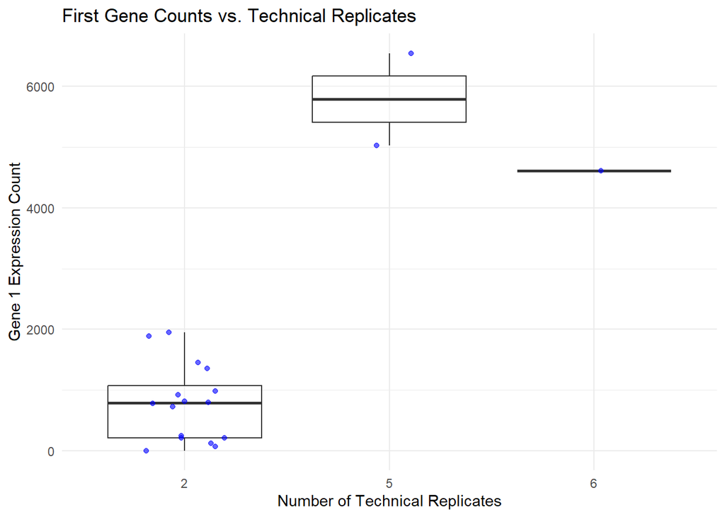

```r
library(ggplot2)
# Create scatter plot with boxplot overlay
ggplot(df, aes(x = replicates, y = gene1_counts)) +
  geom_boxplot(outlier.shape = NA, alpha = 0.3) +  # Boxplot for distribution
  geom_jitter(width = 0.2, color = "blue", alpha = 0.6) +  # Jitter plot for individual points
  labs(title = "First Gene Counts vs. Technical Replicates",
       x = "Number of Technical Replicates",
       y = "Gene 1 Expression Count") +
  theme_minimal()
```

Question 4 Load the Bodymap data with the following command

Fit a linear model relating he first gene’s counts to the age of the person and the sex of the samples. What is the value and interpretation of the coefficient for age?

-23.91. This coefficient means that for each additional year of age, the count goes down by an average of 23.91 for a fixed sex.

```r
# Load required libraries
library(ggplot2)

# Load Bodymap dataset
con = url("http://bowtie-bio.sourceforge.net/recount/ExpressionSets/bodymap_eset.RData")
load(file = con)
close(con)

# Extract expression and metadata
bm = bodymap.eset
edata = exprs(bm)
pdata_bm = pData(bm)

# Debug: Check available metadata
print(colnames(pdata_bm))  # Identify the correct column names
```

```
## [1] "sample.id"     "num.tech.reps" "tissue.type"   "gender"
## [5] "age"           "race"
```

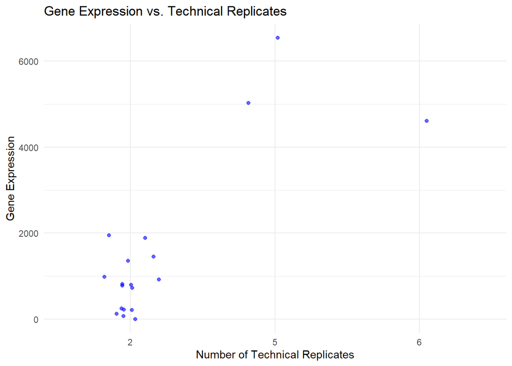

```r
# Extract first gene counts
if(nrow(edata) > 0) {
  gene1_counts = edata[1, ]
} else {
  stop("Error: edata has no genes.")
}

# Extract technical replicates
if("num.tech.reps" %in% colnames(pdata_bm)) {
  replicates = as.factor(pdata_bm$num.tech.reps)
} else {
  stop("Error: 'num.tech.reps' column is missing in pdata_bm.")
}

# Extract age
if("age" %in% colnames(pdata_bm)) {
  age = pdata_bm$age
} else {
  stop("Error: 'age' column is missing in pdata_bm.")
}

# Extract sex (check for alternative column names)
possible_sex_columns = c("sex", "Sex", "gender", "sample_sex")
sex_column = intersect(possible_sex_columns, colnames(pdata_bm))

if(length(sex_column) > 0) {
  sex = as.factor(pdata_bm[[sex_column[1]]])  # Use the first matching column
} else {
  stop("Error: No valid 'sex' column found in pdata_bm.")
}

# Ensure all variables have the same length
if(length(gene1_counts) == length(replicates) && length(replicates) == length(age) && length(age) == length(sex)) {
  df = data.frame(gene1_counts, replicates, age, sex)
} else {
  stop("Error: Mismatch in variable lengths.")
}

# 1️⃣ Scatter Plot: Gene Expression vs. Technical Replicates
ggplot(df, aes(x = replicates, y = gene1_counts)) +
  geom_jitter(width = 0.2, alpha = 0.6, color = "blue") +
  labs(title = "Gene Expression vs. Technical Replicates",
       x = "Number of Technical Replicates",
       y = "Gene Expression") +
  theme_minimal()
```

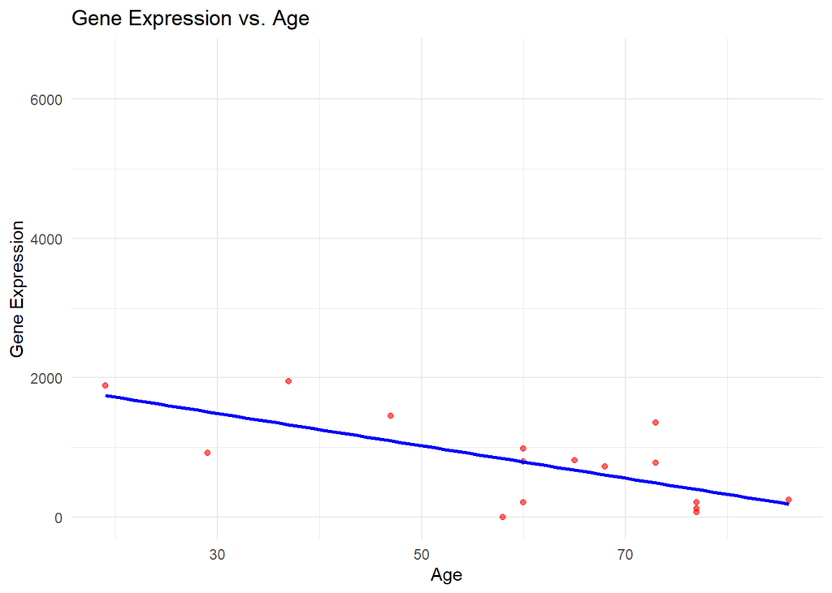

```r
# 2️⃣ Scatter Plot: Gene Expression vs. Age
ggplot(df, aes(x = age, y = gene1_counts)) +
  geom_point(color = "red", alpha = 0.6) +
  geom_smooth(method = "lm", se = FALSE, color = "blue") +
  labs(title = "Gene Expression vs. Age",
       x = "Age",
       y = "Gene Expression") +
  theme_minimal()
```

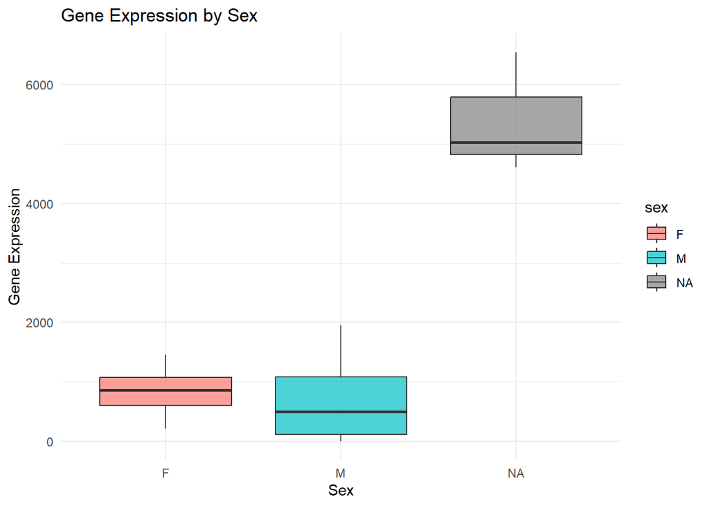

```r
# 3️⃣ Boxplot: Gene Expression by Sex
ggplot(df, aes(x = sex, y = gene1_counts, fill = sex)) +
  geom_boxplot(alpha = 0.7) +
  labs(title = "Gene Expression by Sex",
       x = "Sex",
       y = "Gene Expression") +
  theme_minimal()
```

```r
# 4️⃣ Fit Linear Models
lm_age_sex = lm(gene1_counts ~ age + sex, data = df)
summary(lm_age_sex)
```

```
##
## Call:
## lm(formula = gene1_counts ~ age + sex, data = df)
##
## Residuals:
##     Min      1Q  Median      3Q     Max
## -734.35 -229.31   -3.26  243.02  768.09
##
## Coefficients:
##             Estimate Std. Error t value Pr(>|t|)
## (Intercept) 2331.581    438.181   5.321 0.000139 ***
## age          -23.913      6.488  -3.686 0.002744 **
## sexM        -207.257    236.431  -0.877 0.396610
## ---
## Signif. codes:  0 '***' 0.001 '**' 0.01 '*' 0.05 '.' 0.1 ' ' 1
##
## Residual standard error: 469.6 on 13 degrees of freedom
##   ( 3 個の観測値が欠損のため削除されました )
## Multiple R-squared:  0.5147, Adjusted R-squared:   0.44
## F-statistic: 6.894 on 2 and 13 DF,  p-value: 0.009102
```

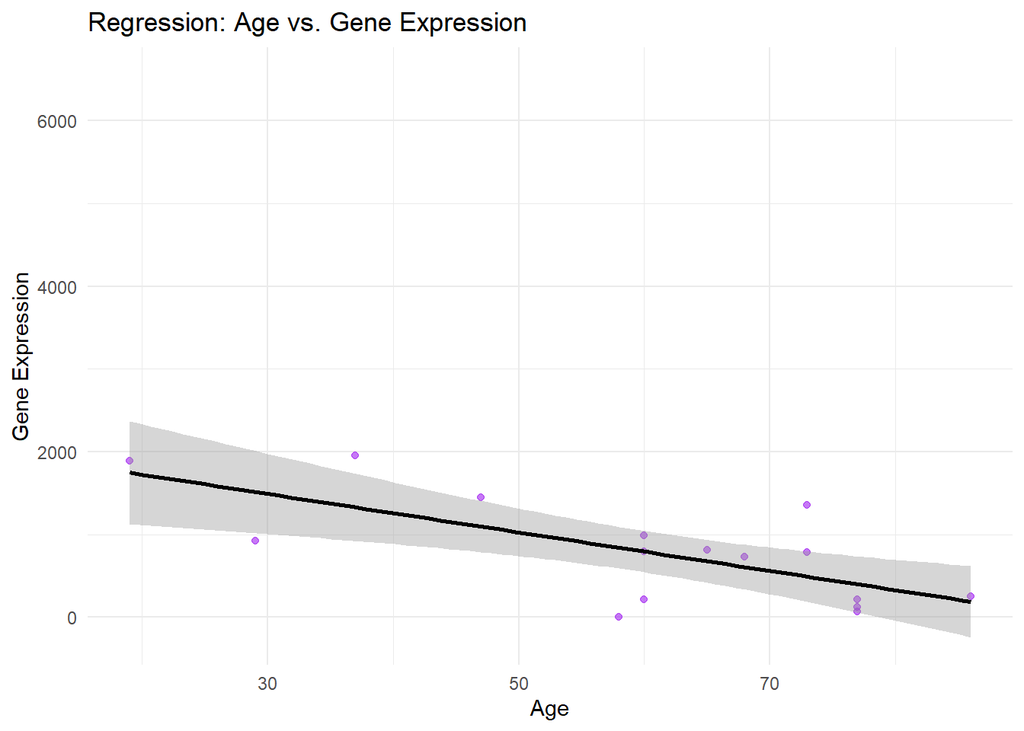

```r
# 5️⃣ Regression Line: Age vs. Gene Expression
ggplot(df, aes(x = age, y = gene1_counts)) +
  geom_point(color = "purple", alpha = 0.6) +
  geom_smooth(method = "lm", se = TRUE, color = "black") +
  labs(title = "Regression: Age vs. Gene Expression",
       x = "Age",
       y = "Gene Expression") +
  theme_minimal()
```

Question 5 Load the Montgomery and Pickrell eSet: Perform the log2(data + 1) transform. Then fit a regression model to each sample using population as the outcome. Do this using the lm.fit lm.fit function (hint: don’t forget the intercept). What is the dimension of the residual matrix, the effects matrix and the coefficients matrix?

Residual matrix: 129 x 52580

Effects matrix: 129 x 52580

Coefficients matrix: 2 x 52580

```r
# Load required libraries
library(stats)

# Load Montgomery & Pickrell dataset
con = url("http://bowtie-bio.sourceforge.net/recount/ExpressionSets/montpick_eset.RData")
load(file = con)
close(con)

# Extract expression data and metadata
mp = montpick.eset
pdata = pData(mp)   # Sample metadata
edata = as.data.frame(exprs(mp))  # Expression data (genes x samples)
fdata = fData(mp)   # Feature (gene) metadata

# Check dataset dimensions
cat("Expression Data Dimensions: ", dim(edata), "\n")  # Expected (genes x samples)
```

```
## Expression Data Dimensions:  52580 129
```

```r
cat("Metadata Dimensions: ", dim(pdata), "\n")  # Expected (samples x metadata variables)
```

```
## Metadata Dimensions:  129 4
```

```r
# Ensure "population" is present in metadata
if(!"population" %in% colnames(pdata)) {
  stop("Error: 'population' column is missing in pdata.")
}

# Convert population to a numeric factor (0,1)
pdata$population = as.numeric(factor(pdata$population))

# Perform log2(data + 1) transformation
log_edata = log2(edata + 1)

# Prepare design matrix for linear model (Intercept + Population)
X = model.matrix(~ pdata$population)  # Creates a (samples x 2) matrix
cat("Design Matrix Dimensions: ", dim(X), "\n")  # Expected (samples x 2)
```

```
## Design Matrix Dimensions:  129 2
```

```r
# Fit the linear model using lm.fit for each gene
fit = lm.fit(X, t(as.matrix(log_edata)))

# Extract results
coefficients_matrix = fit$coefficients  # (2 x genes)
residual_matrix = fit$residuals  # (samples x genes)
effects_matrix = fit$effects  # (samples x genes)

# Print matrix dimensions
cat("Residual Matrix Dimensions: ", dim(residual_matrix), "\n")  # 129 x 52580
```

```
## Residual Matrix Dimensions:  129 52580
```

```r
cat("Effects Matrix Dimensions: ", dim(effects_matrix), "\n")  # 129 x 52580
```

```
## Effects Matrix Dimensions:  129 52580
```

```r
cat("Coefficients Matrix Dimensions: ", dim(coefficients_matrix), "\n")  # 2 x 52580
```

```
## Coefficients Matrix Dimensions:  2 52580
```

Question 6 Load the Montgomery and Pickrell eSet: Perform the log2(data + 1) transform. Then fit a regression model to each sample using population as the outcome. Do this using the lm.fit function (hint: don’t forget the intercept). What is the effects matrix?

```r
# Effects Matrix Interpretation
cat("\nInterpretation of the Effects Matrix:\n")
```

```
##
## Interpretation of the Effects Matrix:
```

```r
cat("The estimated fitted values for all samples for each gene, stored in the columns of the matrix.\n")
```

```
## The estimated fitted values for all samples for each gene, stored in the columns of the matrix.
```